# STAT340 Lecture 10: Linear Regression and Variable Selection

#### Why is ridge regression helpful?

Well, the short answer is that ridge regression (and other shrinkage methods) prevents over-fitting. $\lambda$ makes it more expensive to simply choose whatever coefficients we please, which in turn prevents us from over-fitting to the data.

In essence, this is the bias-variance tradeoff again! As $\lambda$ increases, our freedom to choose the coefficients becomes more constrained, and the variance decreases (and the bias increases).

Here’s an example from ISLR.

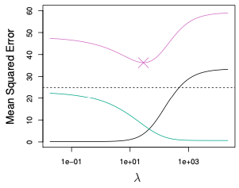

MSE (pink), squared bias (black) and variance (green), estimated from performance on previously unseen data, as a function of $\lambda$ (ISLR fig. 6.5)

### The LASSO

Now, there’s one issue with ridge regression, which becomes evident when we compare it with subset selection methods. Except when $\lambda$ is truly huge (i.e., infinite), ridge regression fits a model that still has all of the coefficients in it (i.e., all of the coefficients are nonzero, though perhaps small). Said another way, we haven’t simplified the model in the sense of reducing the number of predictors or only keeping the “useful” predictors around.

This isn’t a problem for prediction. After all, more predictors often make prediction better, especially when we have regularization to prevent us from over-fitting.

But this *is* a problem if our goal is to simplify our model by selecting only some predictors to include in our model. One way to do this would be to make it so that coefficients that aren’t “pulling their weight” in the sense of helping our prediction error will be set to zero. This is precisely the goal of the LASSO.

**Note:** I (Keith) usually write LASSO in all caps because it is an acronym for *least absolute shrinkage and selection operator*, but it is so wildly popular in statistics that we will often just write Lasso or lasso to refer to it. For those not familiar, a *lasso* is one of [these](https://en.wikipedia.org/wiki/Lasso).

The LASSO looks a lot like ridge regression, except that the penalty is slightly different:
$$\sum_{i=1}^n \left( Y_i - \sum_{j=0}^p \beta_j X_{i,j} \right)^2
+ \lambda \sum_{j=1}^p \left| \beta_j \right|
= \operatorname{RSS} + \lambda \sum_{j=1}^p \left| \beta_j \right|$$

The penalty term now involves a sum of absolute values of the coefficients instead of a sum of squares.

The interesting thing is that this small change has a big effect on what our estimated coefficients look like. The LASSO penalty encourages coefficients to be set *precisely* equal to zero if they aren’t useful predictors (i.e., if they do not help to decrease the RSS).

There is an interesting geometric reason for this, though it is outside the scope of the course. See the end of Section 6.6.2 in ISLR.

The important point is that the LASSO performs *variable selection* for us by setting many coefficients to zero.

The `glmnet` package has a very good LASSO implementation. This is generally a very useful package for doing all kinds of different penalized regression, and you’ll likely use it extensively in your regression course(s). You’ll get a bit of practice with it in discussion section.

### How to choose $\lambda$? CV to the rescue!

A natural question in both ridge and the LASSO concerns how we should choose the term $\lambda$ that controls the “strength” of the penalty term.

We said a few lectures ago that CV was useful beyond just variable selection, and here’s the payoff.

CV is also a great way to choose $\lambda$ in these kinds of *penalized* problems. We choose different values of $\lambda$, fit the corresponding models, and use CV to select among them!

One example:

```r
# make sure you have glmnet installed
library(glmnet)

# peek at data frame
str(mtcars)
```

```
## 'data.frame':    32 obs. of  11 variables:
##  $ mpg : num  21 21 22.8 21.4 18.7 18.1 14.3 24.4 22.8 19.2 ...
##  $ cyl : num  6 6 4 6 8 6 8 4 4 6 ...
##  $ disp: num  160 160 108 258 360 ...
##  $ hp  : num  110 110 93 110 175 105 245 62 95 123 ...
##  $ drat: num  3.9 3.9 3.85 3.08 3.15 2.76 3.21 3.69 3.92 3.92 ...
##  $ wt  : num  2.62 2.88 2.32 3.21 3.44 ...
##  $ qsec: num  16.5 17 18.6 19.4 17 ...
##  $ vs  : num  0 0 1 1 0 1 0 1 1 1 ...
##  $ am  : num  1 1 1 0 0 0 0 0 0 0 ...
##  $ gear: num  4 4 4 3 3 3 3 4 4 4 ...
##  $ carb: num  4 4 1 1 2 1 4 2 2 4 ...
```

```r
head(mtcars)
```

```
##                    mpg cyl disp  hp drat    wt  qsec vs am gear carb
## Mazda RX4         21.0   6  160 110 3.90 2.620 16.46  0  1    4    4
## Mazda RX4 Wag     21.0   6  160 110 3.90 2.875 17.02  0  1    4    4
## Datsun 710        22.8   4  108  93 3.85 2.320 18.61  1  1    4    1
## Hornet 4 Drive    21.4   6  258 110 3.08 3.215 19.44  1  0    3    1
## Hornet Sportabout 18.7   8  360 175 3.15 3.440 17.02  0  0    3    2
## Valiant           18.1   6  225 105 2.76 3.460 20.22  1  0    3    1
```

```r
# use model.matrix to create the "input" data matrix based on a particular formula
# this is just glmnet syntax, input needs to be in matrix form for predictors/response
# [,-1] removes the first column (which is a column of 1's for the intercept)
x = model.matrix(mpg~.,mtcars)[,-1]
y = mtcars$mpg

# fit lasso using default lambda values, alpha=1 adds LASSO penalty to RSS
lm.lasso = glmnet(x,y,alpha=1)

# use CV to choose which lambda gives lowest MSE
cv.out = cv.glmnet(x,y,alpha=1)
lambda.best = cv.out$lambda.min
lambda.best
```

```
## [1] 0.7295713
```

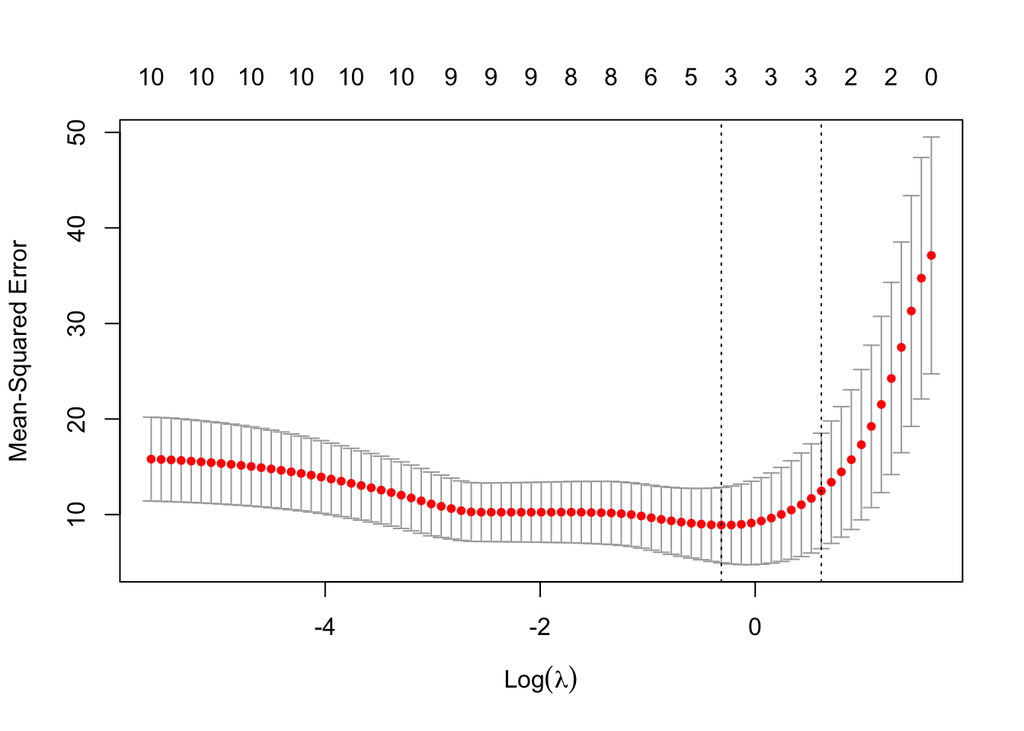

```r
# show MSE for different values of lambda
plot(cv.out)
```

```r
# get coefficients for the best fit
# coefficients eliminated by LASSO (i.e. coefficient fitted to be 0) appear as "."
coef(lm.lasso, s=lambda.best)
```

```
## 11 x 1 sparse Matrix of class "dgCMatrix"
##                      s1
## (Intercept) 36.24450000
## cyl         -0.89103308
## disp         .
## hp          -0.01224851
## drat         .
## wt          -2.74890166
## qsec         .
## vs           .
## am           .
## gear         .
## carb         .
```

```r
# you can use predict with s argument set to your best lambda to get fitted values for new input
predict(lm.lasso, s=lambda.best, newx=as.matrix(mtcars[1,-1]))
```

```
##                 s1
## Mazda RX4 22.34884
```

Section 6.2.3 of ISLR has a more detailed discussion of this.

[^1]: https://stats.stackexchange.com/a/357749